# Practical 1: Dealing with High Dimensional Data

Author

Ward B. Eiling

Published

February 11, 2025

```r
# Load libraries
library(tidyverse)
library(glmnet)
library(caret)
library(here)
```

# 1 Introduction

In this practical, we will deal with the curse of dimensionality by applying the “bet on sparsity”. We will use the following packages in the process:

```
library(tidyverse)
library(glmnet)
```

Create a practical folder with an .Rproj file (e.g., `practical_01.Rproj`) and a data folder inside. Download the prepared files below and put them in the data folder in your project directory.

- gene_expressions.rds
- phenotypes.rds

# 2 Take Home Exercises

## 2.1 Gene expression data

The data file we will be working with is gene expression data. Using microarrays, the expression of many genes can be measured at the same time. The data file contains expressions for 54675 genes with IDs such as `1007_s_at`, `202896_s_at`, `AFFX-r2-P1-cre-3_at`. (NB: these IDs are specific for this type of chip and need to be converted to actual gene names before they can be looked up in a database such as “GeneCards”). The values in the data file are related to the amount of RNA belonging to each gene found in the tissue sample.

The goal of the study for which this data was collected is one of exploratory cancer classification: are there differences in gene expression between tissue samples of human prostates with and without prostate cancer?

**1. Read the data file `gene_expressions.rds` using `read_rds()`. What are the dimensions of the data? What is the sample size?**

```r
gene_exp <- read_rds(here("practical_01_high-dimensional-data/data/gene_expressions.rds"))
gene_exp <- as.data.frame(gene_exp)

dim(gene_exp)[1] # 237 rows/cases
```

```
[1] 237
```

```r
dim(gene_exp)[2] # 54676 columns/features
```

```
[1] 54676
```

```r
# Thus, P > N

length(unique(gene_exp$sample))
```

```
[1] 237
```

**2. As always, visualisation is a good idea. Create histograms of the first 6 variables. Describe what you notice.**

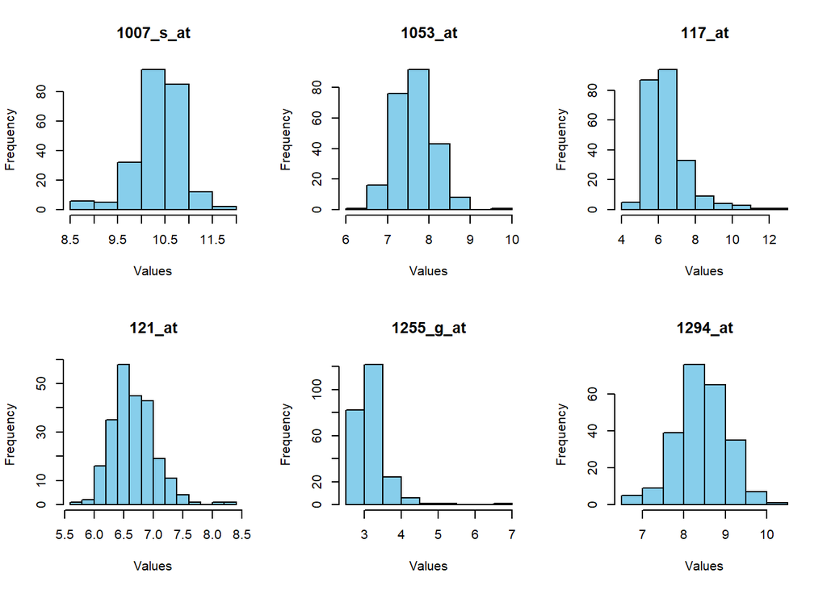

```r
firstsix <- gene_exp[,2:7]
coln <- colnames(firstsix)

par(mfrow = c(2,3))
for (i in 1:6) {
  hist(firstsix[,i], main = coln[i], xlab = "Values", col = "skyblue")
}
```

We can observe that some variables have an approximate normal distributed, albeit with a slight skew (1007_s_at/1053_at/121_at/1294_at), whereas others (1255_g_at/117_at) clearly have a non-symmetric distributed dominated by lower values, indicating lower expression of those genes.

**3. Load phenotypes, select relevant columns, and join with the gene expression data.**

```r
phenotypes <- read_rds(here("practical_01_high-dimensional-data/data/phenotypes.rds")) %>%
  select("sample", "disease")

gene_exp_dis <- right_join(gene_exp, phenotypes, by = "sample")
```

**4. Does this dataset suffer from class imbalance?**

```r
table(gene_exp_dis$disease)
```

```
normal  tumor
   116    121
```

```r
# Observations
# The dataset is balanced for normal/tumor samples, but distributions for variables by disease status may differ.
```

No, the classes are relatively balanced (about 50/50) with 116 healthy samples and 121 tumor samples.

**5. Split the data into a training (80%) and a test set (20%).**

```r
# recode disease into dummy variable where normal = 0 and tumor = 1
gene_exp_dis$disease_dum <- NA
gene_exp_dis$disease_dum[gene_exp_dis$disease == "normal"] <- 1
gene_exp_dis$disease_dum[gene_exp_dis$disease == "tumor"] <- 2
gene_exp_dis$disease_dum <- as.numeric(gene_exp_dis$disease_dum)

set.seed(123)
train_index <- sample(1:nrow(gene_exp_dis), 0.8*nrow(gene_exp_dis))
train <- gene_exp_dis[train_index,]
test <- gene_exp_dis[-train_index,]
```

# 3 Lab Exercises

## 3.1 Correlation filter & logistic regression

**6. Use a correlation filter to find the IDs of the 10 genes most related to disease status.**

```r
genes_train <- train %>% select(-sample, -disease, -disease_dum)
cor_fil <- cor(genes_train, train$disease_dum)
cor_abs <- abs(cor_fil)

# Retrieve top correlations
cor_greatest <- cor_abs %>% as.data.frame() %>% arrange(desc(cor_abs)) %>% head(10)
(sel_genes <- rownames(cor_greatest))
```

```
 [1] "232575_at"   "209424_s_at" "209426_s_at" "206858_s_at" "209425_at"
 [6] "207147_at"   "217111_at"   "242138_at"   "232572_at"   "1559861_at"
```

**7. Perform logistic regression, predicting the outcome using the selected genes.**

```r
train_sel_gens <- train %>% select(sel_genes, disease)
train_sel_gens$disease <- as.factor(train_sel_gens$disease)
fit_lr <- glm(disease ~ ., data = train_sel_gens, family = "binomial")
summary(fit_lr)
```

```
Call:
glm(formula = disease ~ ., family = "binomial", data = train_sel_gens)

Coefficients:
               Estimate Std. Error z value Pr(>|z|)
(Intercept)   -19.90605    4.60597  -4.322 1.55e-05 ***
`232575_at`     0.19527    0.43133   0.453   0.6508
`209424_s_at`   0.11961    0.71459   0.167   0.8671
`209426_s_at`   0.93713    0.77114   1.215   0.2243
`206858_s_at`   0.53675    0.30355   1.768   0.0770 .
`209425_at`    -1.49762    1.04962  -1.427   0.1536
`207147_at`    -0.09836    0.52879  -0.186   0.8524
`217111_at`     1.31406    0.85816   1.531   0.1257
`242138_at`     0.67786    0.44716   1.516   0.1295
`232572_at`     0.72089    0.74412   0.969   0.3326
`1559861_at`    0.79332    0.47859   1.658   0.0974 .
---
Signif. codes:  0 '***' 0.001 '**' 0.01 '*' 0.05 '.' 0.1 ' ' 1

(Dispersion parameter for binomial family taken to be 1)

    Null deviance: 261.369  on 188  degrees of freedom
Residual deviance:  62.755  on 178  degrees of freedom
AIC: 84.755

Number of Fisher Scoring iterations: 8
```

From the logistic regression we can see that none of the genes have a p-value lower than 0.05. In fact, only two genes have a p-value below 0.1. This makes sense as we only used 80% of an already small dataset, making the SE substantial.

**8. Create a confusion matrix for the predictions of this model on the test set.**

```r
test_sel_gens <- test %>% select(sel_genes, disease, sample)
predictions_prob_test <- predict(fit_lr, newdata = test_sel_gens, type = "response")

predictions_df <- data.frame(
  sample = test_sel_gens$sample,
  observed = test_sel_gens$disease,
  test_pred_prob = predictions_prob_test
)

predictions_df$test_pred <- ifelse(predictions_df$test_pred_prob > 0.5, "tumor", "normal")
predictions_df$test_pred <- as.factor(predictions_df$test_pred)
predictions_df$observed <- as.factor(predictions_df$observed)

(cor_log_reg_confusion <- confusionMatrix(predictions_df$test_pred, predictions_df$observed))
```

```
Confusion Matrix and Statistics

          Reference
Prediction normal tumor
    normal     24     1
    tumor       3    20

               Accuracy : 0.9167
                 95% CI : (0.8002, 0.9768)
    No Information Rate : 0.5625
    P-Value [Acc > NIR] : 8.116e-08

                  Kappa : 0.8325

 Mcnemar's Test P-Value : 0.6171

            Sensitivity : 0.8889
            Specificity : 0.9524
         Pos Pred Value : 0.9600
         Neg Pred Value : 0.8696
             Prevalence : 0.5625
         Detection Rate : 0.5000
   Detection Prevalence : 0.5208
      Balanced Accuracy : 0.9206

       'Positive' Class : normal
```

Of the normal samples, our model predicted 24 correct, mistakenly classifying 3 samples as tumor (i.e., false positive). Of the tumor samples, our model predicted 20 correct, mistakenly classifying 1 sample as a normal sample (i.e., a false negative). In the context of the current research question, we would probably care most about minimizing the false negative rate, as we would not like to send patients home who do have a tumor.

## 3.2 Regularized regression

**9. Prepare your data for input into `glmnet`.**

```r
x_train <- as.matrix(train %>% select(-sample, -disease_dum, -disease))
y_train <- as.matrix(train %>% select(disease) %>% mutate(disease = as.factor(disease)))
x_test <- as.matrix(test %>% select(-sample, -disease_dum, -disease))
y_test <- as.matrix(test %>% select(disease) %>% mutate(disease = as.factor(disease)))
```

**10. Use the glmnet function to fit a LASSO regression.**

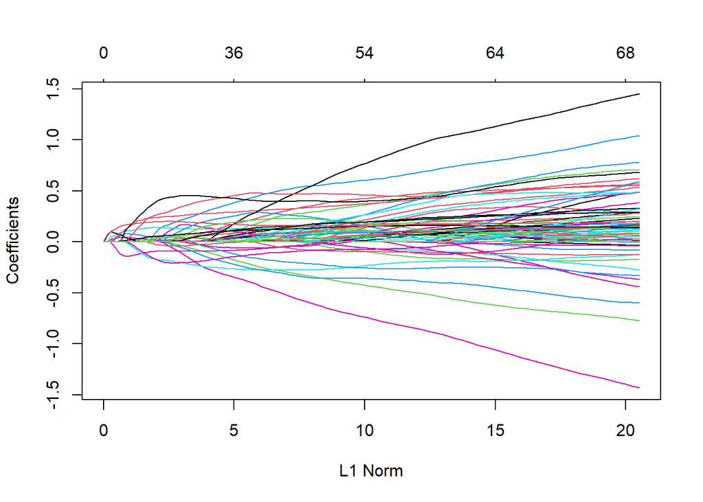

```r
lasso <- glmnet(x_train, y_train, family = "binomial")
plot(lasso)
```

In this plot we can see each line representing a coefficient in the model, with its value on the Y-axis. On the X-axis we can see the total budget. We can see how an an increase in the L1 norm results in a lower penalty/constraint and thus allows a greater budget for the coefficients. As this budget decreases near the left, more parameters shrink to zero.

**11. Use `cv.glmnet` for cross-validated LASSO regression.**

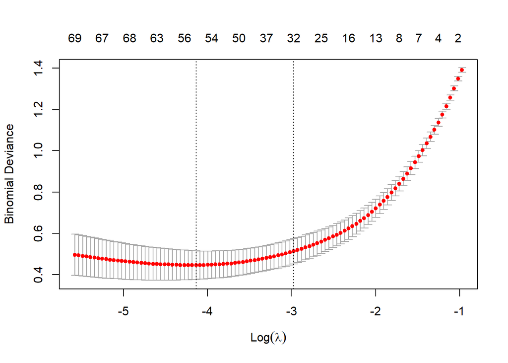

```r
cv_lasso <- cv.glmnet(x_train, y_train, family = "binomial")
plot(cv_lasso)
```

**12. Inspect the nonzero coefficients of the model with the lowest out-of-sample deviance.**

```r
# (cv_coef_SE <- as.data.frame(as.matrix(coef(cv_lasso, s = "lambda.1se"))) %>%
#   filter(s1 != 0))
cv_coef_min <- as.data.frame(as.matrix(coef(cv_lasso, s = "lambda.min"))) %>%
  filter(s1 != 0)
head(cv_coef_min)
```

```
                       s1
(Intercept)  -23.82909715
1552879_a_at   0.08165227
1553316_at     0.28339734
1553561_at     0.41393075
1554321_a_at   0.10336900
1555400_at     0.24240502
```

```r
intersect(sel_genes, rownames(cv_coef_min))
```

```
[1] "232575_at"   "209426_s_at" "206858_s_at" "242138_at"   "232572_at"
```

There are 5 overlapping genes between the two models, so there is partial overlap.

**13. Use the `predict()` function on the fitted `cv.glmnet` object to predict disease status for the test set.**

```r
predicted_cv_lasso <- predict(
  object = cv_lasso,
  newx = x_test,
  s = "lambda.min",
  type = "response"
)

predicted <- ifelse(predicted_cv_lasso[,"lambda.min"] > 0.5, "tumor", "normal")
lasso_cv_confusion <- confusionMatrix(as.factor(predicted), reference = as.factor(y_test))

cor_log_reg_confusion$table # Logistic regression accuracy: 91.67%
```

```
          Reference
Prediction normal tumor
    normal     24     1
    tumor       3    20
```

```r
lasso_cv_confusion$table    # LASSO with CV accuracy: 95.83%
```

```
          Reference
Prediction normal tumor
    normal     26     1
    tumor       1    20
```

Both methods performed well, but LASSO performed slightly better with a greater predictive accuracy on the test set. This is unsurprising as this method performs variable selection in a more rigorous manner.